# Geog533 Lab 5

## Question 4

This is Exercise 7 of the textbook.

A survey of the white and nonwhite population in a local area reveals the following annual trip frequencies to the nearest state park:

$\bar{x_{1}}=4.1$, $s_{1}^{2} = 14.3$, $n_{1} = 20$

$\bar{x_{2}}=3.1$, $s_{2}^{2} = 12.0$, $n_{1} = 16$

where the subscript ‘1’ denotes the white population and the subscript ‘2’ denotes the nonwhite population.

1. Assume that the variances are equal, and test the null hypothesis that there is no difference between the park-going frequencies of whites and nonwhites.
2. Repeat the exercise, assuming that the variances are unequal.
3. Find the p-value associated with the tests in parts (a) and (b).
4. Associated with the test in part (a), find a 95% confidence interval for the difference in means.
5. Repeat parts (a)–(d), assuming sample sizes of n<sub>1</sub> = 24 and n<sub>2</sub> = 12.

```r
###variances are equal
white <- mvrnorm(n=20,mu=4.1,Sigma = 14.3,empirical = TRUE)
n.white <- mvrnorm(n=16,mu=3.1,Sigma = 12,empirical = TRUE)
a<- t.test(white,n.white,var.equal = TRUE)
a
```

```
    Two Sample t-test

data:  white and n.white
t = 0.81797, df = 34, p-value = 0.4191
alternative hypothesis: true difference in means is not equal to 0
95 percent confidence interval:
 -1.484493  3.484493
sample estimates:
mean of x mean of y
      4.1       3.1
```

```r
if(a$p.value>0.05){print ("we cannot reject the null hypothesis")
}else{print("we reject the null hypothesis")}
```

```
[1] "we cannot reject the null hypothesis"
```

```r
print("Therefore there is no difference between the park-going frequencies of whites and nonwhites.")
```

```
[1] "Therefore there is no difference between the park-going frequencies of whites and nonwhites."
```

```r
###variances are unequal
white <- mvrnorm(n=20,mu=4.1,Sigma = 14.3,empirical = TRUE)
n.white <-  mvrnorm(n=16,mu=3.1,Sigma = 12,empirical = TRUE)
b <- t.test(white,n.white,var.equal = FALSE)
print(b)
```

```
    Welch Two Sample t-test

data:  white and n.white
t = 0.82619, df = 33.323, p-value = 0.4146
alternative hypothesis: true difference in means is not equal to 0
95 percent confidence interval:
 -1.461613  3.461613
sample estimates:
mean of x mean of y
      4.1       3.1
```

```r
if(b$p.value>0.05){print ("we cannot reject the null hypothesis")
}else{print("we reject the null hypothesis")}
```

```
[1] "we cannot reject the null hypothesis"
```

```r
print("Therefore there is no difference between the park-going frequencies of whites and nonwhites.")
```

```
[1] "Therefore there is no difference between the park-going frequencies of whites and nonwhites."
```

```r
###the p-values;
print(a$p.value)
```

```
[1] 0.4190693
```

```r
print(b$p.value)
```

```
[1] 0.4145715
```

```r
### 95% confidence interval for part a;
print(a$conf.int)
```

```
[1] -1.484493  3.484493
attr(,"conf.level")
[1] 0.95
```

```r
###part e
####equal variances
white <- mvrnorm(n=24,mu=4.1,Sigma = 14.3,empirical = TRUE)
n.white <- mvrnorm(n=12,mu=3.1,Sigma = 12,empirical = TRUE)
ae<- t.test(white,n.white,var.equal = TRUE)
ae
```

```
    Two Sample t-test

data:  white and n.white
t = 0.76821, df = 34, p-value = 0.4477
alternative hypothesis: true difference in means is not equal to 0
95 percent confidence interval:
 -1.645421  3.645421
sample estimates:
mean of x mean of y
      4.1       3.1
```

```r
if(ae$p.value>0.05){print ("we cannot reject the null hypothesis")
}else{print("we reject the null hypothesis")}
```

```
[1] "we cannot reject the null hypothesis"
```

```r
print("Therefore there is no difference between the park-going frequencies of whites and nonwhites.")
```

```
[1] "Therefore there is no difference between the park-going frequencies of whites and nonwhites."
```

```r
####unequal variances;
white <- mvrnorm(n=24,mu=4.1,Sigma = 14.3,empirical = TRUE)
n.white <-  mvrnorm(n=12,mu=3.1,Sigma = 12,empirical = TRUE)
be <- t.test(white,n.white,var.equal = FALSE)
print(be)
```

```
    Welch Two Sample t-test

data:  white and n.white
t = 0.7916, df = 23.947, p-value = 0.4364
alternative hypothesis: true difference in means is not equal to 0
95 percent confidence interval:
 -1.607549  3.607549
sample estimates:
mean of x mean of y
      4.1       3.1
```

```r
if(be$p.value>0.05){print ("we cannot reject the null hypothesis")
}else{print("we reject the null hypothesis")}
```

```
[1] "we cannot reject the null hypothesis"
```

```r
print("Therefore there is no difference between the park-going frequencies of whites and nonwhites.")
```

```
[1] "Therefore there is no difference between the park-going frequencies of whites and nonwhites."
```

```r
####p.values
print(ae$p.value)
```

```
[1] 0.4476643
```

```r
print(be$p.value)
```

```
[1] 0.4363646
```

```r
####95% confidence interval
print(ae$conf.int)
```

```
[1] -1.645421  3.645421
attr(,"conf.level")
[1] 0.95
```

## Question 5

This is Exercise 9 of the textbook.

A researcher suspects that the level of a particular stream’s pollutant is higher than the allowable limit of 4.2 mg/l. A sample of n = 17 reveals a mean pollutant level of = 6.4 mg/l, with a standard deviation of 4.4 mg/l. Is there sufficient evidence that the stream’s pollutant level exceeds the allowable limit? What is the p-value?

```r
x <- mvrnorm(n=17,mu=6.4,Sigma = 4.4^2,empirical = TRUE)
result <- t.test(x,mu=4.2,alternative = "greater")
print(result)
```

```
    One Sample t-test

data:  x
t = 2.0616, df = 16, p-value = 0.02794
alternative hypothesis: true mean is greater than 4.2
95 percent confidence interval:
 4.536868      Inf
sample estimates:
mean of x
      6.4
```

```r
if(result$p.value>0.05){print ("we cannot reject the null hypothesis")
}else{print("we reject the null hypothesis")}
```

```
[1] "we reject the null hypothesis"
```

```r
print("Therefore the stream's pollutant is higher than the allowable limit.")
```

```
[1] "Therefore the stream's pollutant is higher than the allowable limit."
```

## Question 6

This is Exercise 13 of the textbook.

Suppose we want to know whether the mean length of unemployment differs among the residents of two local communities. Sample information is as follows:

Community A: sample mean = 3.4 months, s = 1.1 month, n = 52

Community B: sample mean = 2.8 months, s = 0.8 month, n = 62

Set up the null and alternative hypotheses. Use α = 0.05. Choose a particular test, and show the rejection regions on a diagram. Calculate the test statistic, and decide whether to reject the null hypothesis. (Do not assume that the two standard deviations are equal to one another – therefore a pooled estimate of s should not be found.)

```r
a <- mvrnorm(n=52, mu=3.4, Sigma = 1.1^2,empirical = TRUE )
b <- mvrnorm(n=62, mu=2.8, Sigma = 0.8^2,empirical = TRUE )
results <- t.test(a,b,var.equal = FALSE)
results
```

```
    Welch Two Sample t-test

data:  a and b
t = 3.2737, df = 91.269, p-value = 0.0015
alternative hypothesis: true difference in means is not equal to 0
95 percent confidence interval:
 0.2359499 0.9640501
sample estimates:
mean of x mean of y
      3.4       2.8
```

```r
if(result$p.value>0.05){print ("we cannot reject the null hypothesis")
}else{print("we reject the null hypothesis")}
```

```
[1] "we reject the null hypothesis"
```

```r
print("mean length of unemployment differs among residents")
```

```
[1] "mean length of unemployment differs among residents"
```

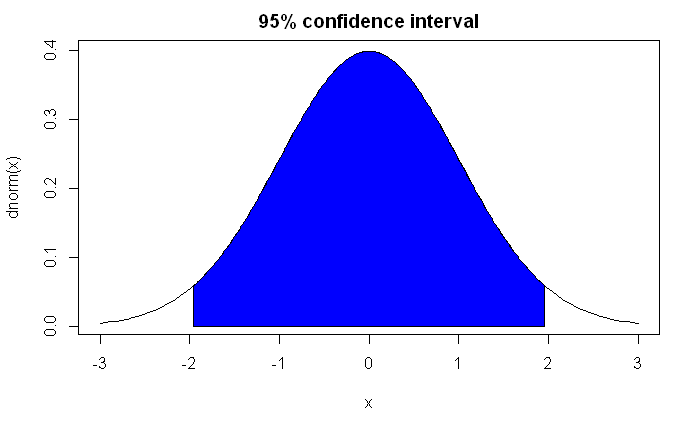

```r
q95 <- qnorm(0.975)  # 95% confidence interval
curve(dnorm,from = -3,to = 3,main="95% confidence interval")
x <- c(-q95,seq(-q95,q95,by = 0.01),q95)
y <- c(0,dnorm(seq(-q95,q95,by = 0.01)),0)
polygon(x,y,col="blue")####the unshaded area is the rejection region.
```

## Question 7

This is Exercise 15 of the textbook.

Find the 90% and 95% confidence intervals for the following mean stream link lengths:

100, 426, 322, 466, 112, 155, 388, 1155, 234, 324, 556, 221, 18, 133, 177, 441.

```r
x <- c(100,426,322,466,112,155,388,1155,234,324,556,221,18,133,177,441)
q90 <- t.test(x,conf.level =0.90)
print(q90)
```

```
    One Sample t-test

data:  x
t = 4.8558, df = 15, p-value = 0.0002097
alternative hypothesis: true mean is not equal to 0
90 percent confidence interval:
 208.7856 444.7144
sample estimates:
mean of x
   326.75
```

```r
print(q90$conf.int)
```

```
[1] 208.7856 444.7144
attr(,"conf.level")
[1] 0.9
```

```r
q95 <- t.test(x,conf.level =0.95)
q95
```

```
    One Sample t-test

data:  x
t = 4.8558, df = 15, p-value = 0.0002097
alternative hypothesis: true mean is not equal to 0
95 percent confidence interval:
 183.3228 470.1772
sample estimates:
mean of x
   326.75
```

```r
print(q95$conf.int)
```

```
[1] 183.3228 470.1772
attr(,"conf.level")
[1] 0.95
```